# Bayesian Optimisation

Yuji Saikai ysaikai@unimelb.edu.au School of Mathematics and Statistics The University of Melbourne

# Introduction

In contrast to the methods for local optimisation, Bayesian optimisation (BO) is a technique for global optimisation. A typical case in which BO shines is characterised by the following.

- Black-box objective function $h$, i.e. while $h$ can be evaluated, no closed-form expression is available.
- Each evaluation of $h$ is expensive.
- No direct access to the gradient $\nabla h$.

Just like other numerical optimisation techniques, BO searches for an optimum point $x^*$ by sequentially evaluating $h$. However, without closed-form expression, each evaluation tends to be too slow for standard techniques, which often require hundreds or thousands of evaluations. BO addresses the challenge by maintaining and utilising statistical estimates of $h$, for which a close-form expression is available. The machinery of BO consists of:

- Gaussian process surrogate models for estimating $h$, and
- Acquisition function for prescribing the next evaluation point.

These two components dynamically interact with each other to achieve efficient global optimisation.

## Global optimisation

A global minimisation problem is
$$\min_{x\in\mathcal{D}} h(x)$$
where $h$ is the objective function and $\mathcal{D}$ is a subset of the function’s domain, over which we try to find a minimiser $x^*$ such that $h(x^*)\leq h(x)$ for all $x\in\mathcal{D}$.

The fundamental challenge arises from our limited knowledge of the shape of $h$. Unless $h$ is fairly simple such as low-degree polynomials and sinusoids, it is usually hard to get a global picture from the expression of $h$ even in 1-D cases. Most of the times, therefore, we evaluate $h$ at a finite number of points and interpolate them.

For example, the test function used in the optimisation notes
$$f(x) = \frac{\sin(3\pi x)}{x}+x^3-5x^2+6x$$
has the global minimum $-1.025$ at $x=2.5$. The following graph is produced by first evaluating $h$ at 101 evenly spaced points from 0.3 to 3.5 and then connecting the dots.

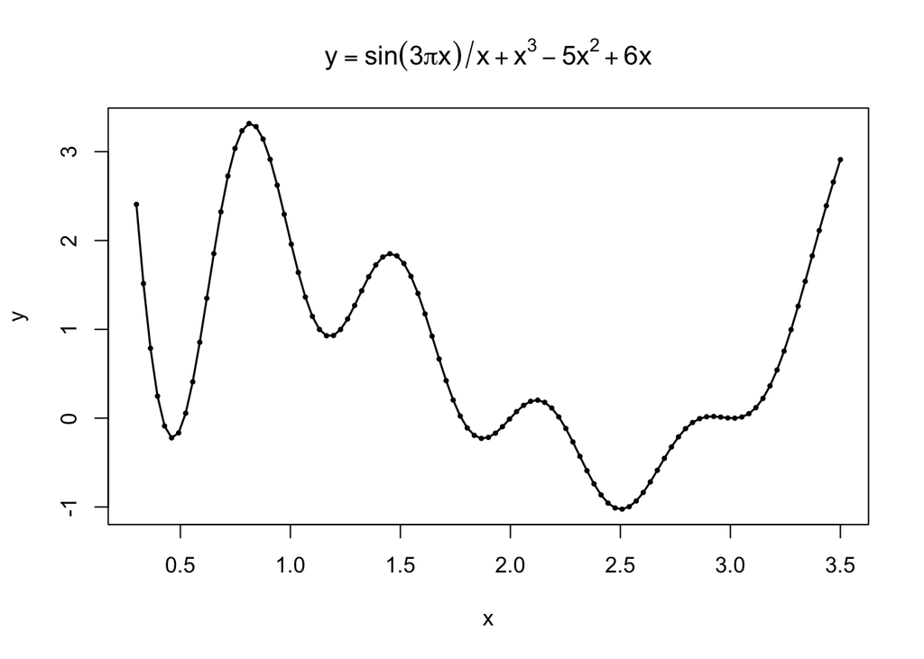

With the picture, we can easily pick the best one (70th point) among 101 points as an approximate minimiser $\hat{x}^*=2.508$ yielding $h(\hat{x}^*)=-1.024$, which is pretty close to the global minimum.

Comparing to this simple yet effective approach, we notice something naïve in gradient descent; it does not utilise information that can be extracted from the evaluated points. Instead, it ignores the history, uses only local information (i.e. the gradient), and blindly follows its direction at each step. As a result, if using random initial points to find the global minimum, on average, we must repeat the process many times.

## Surrogate models

Seeing those evaluated points as data, don’t you think the above interpolation is akin to statistical regression? In regression, we collect data $(X,y)$ and estimate the underlying data-generating process by fitting some models to the data. In the above case, using the evenly-spaced points $X$ and the corresponding objective values $y$, we essentially estimate the underlying objective function by connecting the dots.

> If you are new to regression, you may take it as prediction of $h(\tilde{x})$ for new $\tilde{x}$ using a curve fitted to $(X,y)$.

In most regression problems, our statistical models are more sophisticated than connecting dots (e.g., linear, polynomial, neural network, etc.). So, why don’t we use such statistical models for optimisation as well? It is reasonable to expect that suitable models extract useful information from evaluated points about the objective function and, in particular, promising regions for minimisers, leading to more efficient search. In this context, models for objective functions are commonly called **surrogates**. Gaussian process is the de facto standard surrogate model in BO.

> “Connecting dots” can be seen as a special case of spline or local regression.

# Bayesian statistics

In terms of mathematical structure, Gaussian process is a stochastic process. When used to make inferences based on data, however, it is more useful to see Gaussian process as a Bayesian statistical model. Despite the slight digression, let’s briefly review the essence of Bayesian statistics.

## Bayesian models

In statistics, we are interested in learning about unknown quantities of interest (e.g., system parameters) from data. Bayesians approach the problem by modelling those unknown quantities as random variables. Suppose that a system is governed by parameter $\alpha$, and system’s output $x$ is observable. First, to make $\alpha$ learnable from data $x$, we restrict the distribution of $\alpha$ to a certain class. In addition, even with true $\alpha$, we are humble and do not think our model completely captures the underlying deterministic mechanism. So, we assume $x$ follows some probability distribution parameterised by $\alpha$.

In Bayesian statistics,

- Likelihood : $f(x|\alpha)$, the conditional PMF/PDF for $x$ given $\alpha$,
- Prior : $f(\alpha)$, the marginal PMF/PDF for $\alpha$, and
- Posterior : $f(\alpha|x)$, the conditional PMF/PDF for $\alpha$ given $x$.

The central object to learn about is the posterior, which is given by the Bayes’ formula:
$$f(\alpha|x) =
\frac{f(x,\alpha)}{f(x)} = \frac{f(x|\alpha)f(\alpha)}{\int
f(x|\alpha)f(\alpha) d\alpha} \propto f(x|\alpha)f(\alpha).$$

> In the classical (a.k.a. frequentist) statistics, the same mathematical expression $f(x;\alpha) = f(x|\alpha)$ is viewed as a function of $\alpha$ for fixed $x$. For example, $\hat{\alpha}_{MLE} \in \underset{\alpha}{\operatorname{argmax}} f(x;\alpha)$.

## Hierarchical models

In practice, assuming $\alpha \sim f(\alpha)$ is often too strong/rigid to flexibly capture complex phenomena. As stated above, we want to restrict the distribution of $\alpha$ only to a class of distributions, not a particular distribution. But, if we say $f(\alpha)$ is the prior, there is no flexibility — $\alpha$ must follow $f(\alpha)$. One of the easiest ways to relax the rigid assumption is to introduce another conditional PMF/PDF for $\alpha$ given, say, $\beta$. The posterior is now:
$$f(\alpha,\beta|x) =
\frac{f(x,\alpha,\beta)}{f(x)} \propto
f(x|\alpha,\beta)f(\alpha|\beta)f(\beta) =
f(x|\alpha)f(\alpha|\beta)f(\beta).$$

> Typically, we define the model such that $f(x|\alpha) = f(x|\alpha,\beta)$, the likelihood does not depend on $\beta$.

Since $\alpha$ is the parameter of interest, we integrate out hyperparameter $\beta$ and get the marginal posterior for $\alpha$
$$f(\alpha|x) = \int f(\alpha,\beta|x)
d\beta.$$

There are often multiple integrals involved in Bayesian hierarchical models. Aside from $f(x)=\int f(x|\alpha)f(\alpha) d\alpha$, a key one is
$$\begin{align}
\mathbb{E}[\alpha|x]
&= \int \alpha f(\alpha|x) d\alpha\\
&= \int \alpha \int f(\alpha,\beta|x) d\beta d\alpha.
\end{align}$$

When faced with difficult integrals, modellers have choices to make. For example,

- Make integrals analytically tractable by imposing [conjugate priors](https://en.wikipedia.org/wiki/Conjugate_prior).
- Make integrals amenable to basic Gibbs sampling by deliberately choosing priors such that all full conditionals are easy to sample from. This is the approach taken in the example.
- Keep the model faithful to the problem/domain knowledge and deal with difficult integrals using the general Metropolis-Hastings algorithm.
- Blend multiple sampling techniques within a Gibbs-sampling framework. That is, off-the-shelf samplers, inverse transform, rejection sampling, general MCMC methods, etc. are used for different full conditionals.

In principle, we can go deeper and introduce more levels to the hierarchy. In practice, however, we usually stop at the first or second levels for hyperparameters (or hyper-hyper-parameters) and just assume a prior for hyperparameters at the end of the hierarchy. In the above example, we may directly assume the prior $f(\beta)$ instead of, say, $\beta \sim f(\beta|\gamma)$.

## Empirical Bayes

In other times in practice, we may give up even assuming a prior for $\beta$ and treat $\beta$ as a deterministic parameter. In this case,
$$f(\alpha|\beta,x) =
\frac{f(x,\alpha|\beta)}{f(x)} \propto
f(x|\alpha)f(\alpha|\beta).$$
Clearly, to make inferences about $\alpha$ based on the posterior $f(\alpha|\beta,x)$, we need a value of $\beta$ to use in the above expression. What value and how to get it?

A common technique is called **empirical Bayes** method (a.k.a. **type II maximum likelihood**). In contrast to the standard MLE, which maximises the likelihood $f(x|\alpha)$ with respect to $\alpha$, the empirical Bayes method maximises the **marginal likelihood** $f(x|\beta)$ with respect to $\beta$.

First, integrate out $\alpha$ from $f(x,\alpha|\beta)$ to get the marginal likelihood of $\beta$:
$$f(x|\beta) = \int f(x,\alpha|\beta)
d\alpha.$$
Then, maximise $f(x|\beta)$ to obtain a point estimate
$$\hat{\beta} \in
\underset{\beta}{\operatorname{argmax}} f(x|\beta)$$
and plug it in $f(\alpha|\beta)$. Now, we make inferences about $\alpha$ based on $f(x|\alpha)f(\alpha|\hat{\beta})$.

Note that the use of point estimate $\hat{\beta}$ is conceptually quite different from obtaining $f(\alpha|x)$ by integrating out $\beta$ from $f(\alpha,\beta|x)$, which averages out the effect of hyperparameter over all possible values of $\beta$. Although starting with the prior assumption on $\alpha$, empirical Bayes is much less Bayesian.

# Gaussian process

## Definition

Gaussian process (GP) is a collection of random variables (i.e., stochastic process) such that **any finite sub-collection follows a multivariate normal distribution**.

> Remember Poisson process is a stochastic process specified by rate $\lambda$. For a counting process, we use a set of nonnegative real numbers $\mathbb{R}_+$ as an index set, with which for some epoch $t\in\mathbb{R}_+$ of interest, we have a counting random variable $N(t)\sim\text{pois}(\lambda t)$.

> You may also find GP classified as Bayesian nonparametric in statistics and machine learning. It is **nonparametric** because there is no parameter vector directly corresponding to $\alpha$ in the above structure; technically, there are an infinite number of parameters.

To satisfy the above condition, a GP is specified by mean function $m$ and covariance function $k$. We write
$$g\sim\mathcal{GP}(m,k)$$
to mean that Gaussian process $g$ is specified by $m$ and $k$. As the names suggest, $m(x_i)$ returns the mean for point $x_i$ and $k(x_i,x_j)$ returns the covariance for a pair of points $(x_i,x_j)$:
$$\begin{align}
m(x_i) &= \mathbb{E}[g(x_i)]\\
k(x_i,x_j) &= \mathbb{E}[(g(x_i)-m(x_i))(g(x_j)-m(x_j))].
\end{align}$$

For a single point $x$, $\mathcal{GP}(m,k)$ returns $g(x) \sim \text{N}(m(x),k(x,x))$. For multiple points $(x_1,\dots,x_n)$, $\mathcal{GP}(m,k)$ returns $\text{N}(\mu, \Sigma)$, a normal random vector
$$\mathbf{g} =
\begin{bmatrix}
g(x_1)\\
\vdots\\
g(x_n)
\end{bmatrix}$$
specified by
$$\mu =
\begin{bmatrix}
m(x_1)\\
\vdots\\
m(x_n)
\end{bmatrix}
\quad\text{and}\quad
\Sigma =
\begin{bmatrix}
k(x_1,x_1) & \dots & k(x_1,x_n)\\
\vdots & \ddots & \vdots\\
k(x_n,x_1) & \dots & k(x_n,x_n)
\end{bmatrix}.$$

Intuitively, $k(x_i,x_j)$ measures similarity between $g(x_i)$ and $g(x_j)$. For example, if two points $x_i$ and $x_j$ are “close” in some metric (e.g., Euclidean distance), the corresponding random variables $g(x_i)$ and $g(x_j)$ should be strongly correlated.

> Remember the property of normal distribution. To have the joint PDF, in practice, we define $k$ such that $\Sigma$ is positive definite.

Notice that the number of points given to GP at once is arbitrary. Thus, essentially, GP defines a **probability distribution over functions**. We are familiar with a random vector specified by a probability distribution over vectors. Now, imagine those vectors are of infinite length.

These specifications form a GP **prior** distribution (over functions).

### Demo

Let’s see what GP realisation looks like, using one of the most basic configurations: $m(x_i) = 0$ and $k(x_i,x_j) = \exp(-\|x_i-x_j\|^2)$. Suppose 151 points $\{x_1,\dots,x_{151}\}$ equally-spaced over $[0.3,3.5]$.

```r
# Covariance function
k <- function(x1, x2, theta) {
  s <- theta[1]
  l <- theta[2]
  return(s^2*exp(-sum(((x1-x2)/l)^2)))
}

# Compute a relevant sub-matrix
kk <- function(X1, X2=NULL, theta=c(1,1,0)) {
  I <- dim(X1)[1]

  # K11 & K22
  if (is.null(X2)) {
    K <- matrix(0, nrow=I, ncol=I)
    for (i in 1:I) {
      for (j in 1:i) {
        K[i,j] <- k(X1[i,], X1[j,], theta)
      }
    }
    # K11 & K22 are symmetric
    K[upper.tri(K)] <- t(K)[upper.tri(K)]
  # K12 & K21
  } else {
    J <- dim(X2)[1]
    K <- matrix(0, nrow=I, ncol=J)
    for (i in 1:I) {
      for (j in 1:J) {
        K[i,j] <- k(X1[i,], X2[j,], theta)
      }
    }
  }

  return(K)
}
```

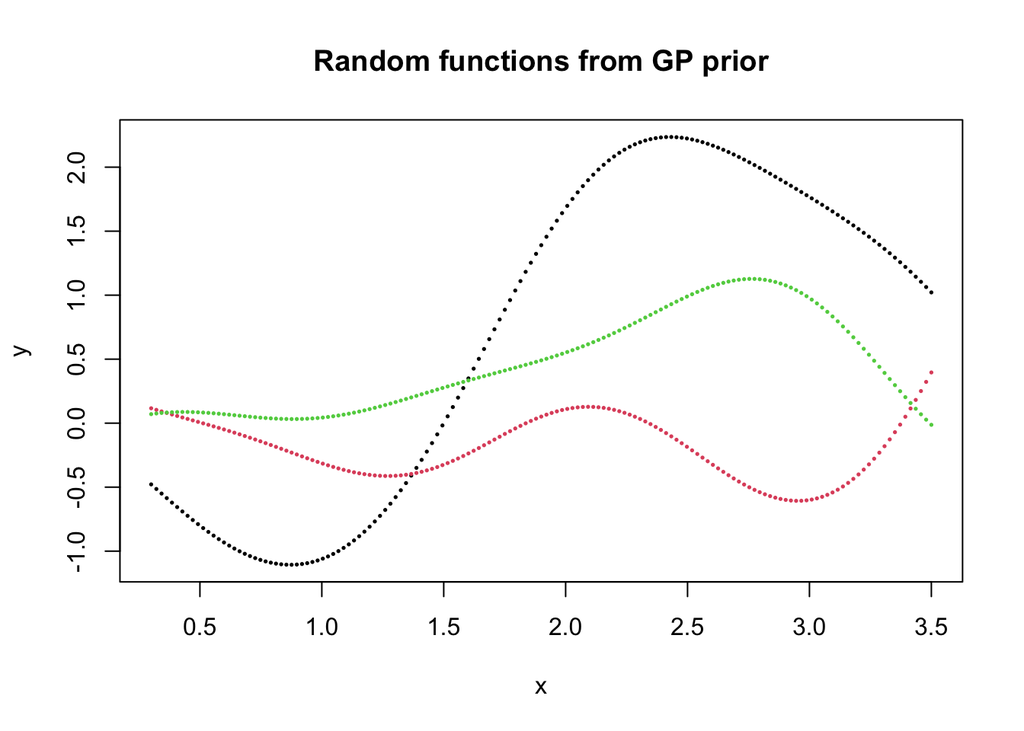

```r
X <- matrix(seq(.3, 3.5, length.out=m), ncol=1) # points
K <- kk(X)
Y <- mvrnorm(3, rep(0,m), K)
matplot(X, t(Y), lwd=1.2, pch=20, cex=0.3, xlab="x", ylab="y")
title("Random functions from GP prior")
```

As clearly indicated in the above code, we draw three random vectors of length 151 from the multivariate normal and plot each set of 151 realisations separately. When many points are given, they collectively look like randomly drawn functions.

## Regression

Recall the following property of normal distribution. Suppose that a normal random vector $z$ is partitioned into $z_1$ and $z_2$ as follows:
$$\begin{bmatrix}
z_1\\
z_2
\end{bmatrix}
\sim \mathrm{N}(0,\Sigma),$$
where
$$\Sigma =
\begin{bmatrix}
\Sigma_{11} & \Sigma_{12}\\
\Sigma_{21} & \Sigma_{22}
\end{bmatrix}
.$$
Then, the conditional distribution of $z_1$ given $z_2$ is also normal
$$z_1|z_2 \sim
\mathrm{N}(\bar{\mu},\bar{\Sigma}),$$
where
$$\bar{\mu} = \Sigma_{12}\Sigma_{22}^{-1}z_2 \quad\text{and}\quad
\bar{\Sigma} = \Sigma_{11} - \Sigma_{12} \Sigma_{22}^{-1} \Sigma_{21}.$$

We use this property to obtain a GP **posterior**. First, assume that the **likelihood** of $y$ at $x$ given $g(x)$ is the conditional PDF $f(y|g(x))$ specified by $\text{N}(g(x),\sigma^2)$. That is,
$$y = g(x) + \epsilon,$$
where $\epsilon \sim \text{N}(0,\sigma^2)$.

In GP regression, new $\tilde{y}$ at $\tilde{x}$ is predicted using the posterior GP given the data:
$$D_n = (X,y) =
\{(x_i,y_i)\}_{i=1}^n.$$
When predicting new $\tilde{y}$, we may ignore the observation error $\epsilon$. Now, consider the following random vector:
$$\begin{bmatrix}
g(\tilde{x})\\
y
\end{bmatrix}
\sim \mathrm{N}(0,K),$$
where
$$K =
\begin{bmatrix}
\mathbf{k}(\tilde{x},\tilde{x}) & \mathbf{k}(\tilde{x},X)\\
\mathbf{k}(X,\tilde{x}) & \mathbf{k}(X,X)+\sigma^2I
\end{bmatrix},$$
and $\mathbf{k}$ denotes a matrix of appropriate size whose elements are obtained by applying $k$ element-wise.

> If $\tilde{x}$ is a single point, $\mathbf{k}(\tilde{x},X)$ is in $1\times n$, $\mathbf{k}(X,\tilde{x})$ is in $n\times 1$, and $\mathbf{k}(X,X)$ is in $n\times n$.

Using the above property of normal distribution, the conditional distribution of $g(\tilde{x})$ given $D_n$ is
$$g(\tilde{x})|D_n \sim
\text{N}\left(\hat{\mu}(\tilde{x}),\;\hat{K}(\tilde{x})\right),$$
where
$$\begin{align}
\hat{\mu}(\tilde{x}) &=
\mathbf{k}(\tilde{x},X)(\mathbf{k}(X,X)+\sigma^2I)^{-1}y\\
\hat{K}(\tilde{x}) &= \mathbf{k}(\tilde{x},\tilde{x}) -
\mathbf{k}(\tilde{x},X) (\mathbf{k}(X,X)+\sigma^2I)^{-1}
\mathbf{k}(X,\tilde{x}).
\end{align}$$

Notice that both $\hat{\mu}$ and $\hat{K}$ are functions of $\tilde{x}$. Thus, we may use $\hat{\mu}$ as point-wise prediction of $\tilde{y}$ at $\tilde{x}$ and $\hat{K}$ to form an interval prediction.

If we allow arbitrary $\tilde{x}$ to consist of multiple points $(\tilde{x}_1,\dots,\tilde{x}_m)$, we can see that $\hat{\mu}$ provides a mean vector and $\hat{K}$ provides a covariance matrix. Hence, $g(\tilde{x})|D_n$ defines another GP, which is the posterior GP.

### Demo

Generate data without noise (i.e. $\sigma^2=0$) by evaluating $h$ at evenly spaced 15 points, $x\in[0.3, 3.5]$.

```r
n <- 15
sig <- 0
X <- matrix(seq(0.3, 3.5, length.out=n), ncol=1) # data
y <- h(X) + rnorm(n, sd=sig) # data
```

The following graph traces $\hat{\mu}(\tilde{x})$ computed conditional on these data points.

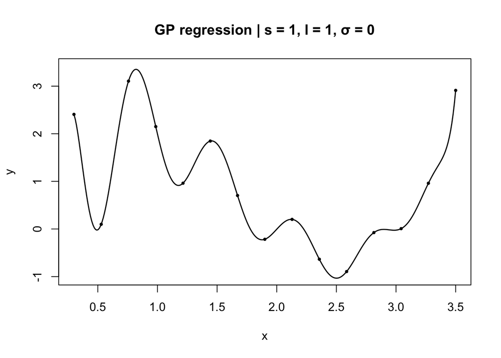

```r
# x.tilde
m <- 301
xx <- matrix(seq(.3, 3.5, length.out=m), ncol=1)

# Covariance matrix
K11 <- kk(xx)
K12 <- kk(xx, X)
K21 <- t(K12)
K22 <- kk(X) + diag(sig^2, n)

# Posterior GP
mu.hat <- K12%*%solve(K22,y)
K.hat <- K11 - K12%*%solve(K22,K21) # Unused

# Plot
plot(xx, mu.hat, type="l", lwd=1.5, ylim=c(-1,3.4), xlab="x", ylab="y")
points(X, y, pch=20, cex=0.7)
title("GP regression | s = 1, l = 1, σ = 0")
```

## Hyperparameters

As done above, it is common to assume $m(x)=0, \forall x$. In this case, performance of GP solely depends on quality of the covariance function $k$, which plays a role of $\alpha$ in the context of hierarchical models. To increase the flexibility of $k$, we introduce hyperparameters to $k$.

Previously, we have $k(x_i,x_j)=\exp(-\|x_i-x_j\|^2)$. Let’s introduce two hyperparameters $s^2$ and $l$, which may be interpreted as **variance** and **length-scale** respectively in the following way:
$$k(x_i,x_j;s^2,l) =
s^2\exp\left(-\left\|\frac{x_i-x_j}{l}\right\|^2\right).$$
$s^2$ is easy to interpret by noting $k(x,x)=s^2$, the variance of $g(x)$. Now, we have flexibility in the spread of normal random variables.

Next, remember that $k(x_i,x_j)$ measures the similarity of $g(x_i)$ and $g(x_j)$ based on the distance between $x_i$ and $x_j$. Clearly, there are fixed upper and lower bounds: $\|x_i-x_j\|=0$ implies $\text{Cov}(g(x_i),g(x_j))=s^2$ and $\|x_i-x_j\|=\infty$ implies $\text{Cov}(g(x_i),g(x_j))=0$. However, it would be nice to have some flexibility in between because the correspondence between distance in $x$ and similarity in $g(x)$ may not be so obvious. The length-scale hyperparameter $l$ allows us to adjust this correspondence. The larger $l$, the more similar $g(x_i)$ and $g(x_j)$ for the given distance between $x_i$ and $x_j$.

> There are many variants of covariance function. The current one is the most basic one, classified as isotropic: $k(x_i,x_j)=k_1(\|x_i-x_j\|)$. A more general one is stationary but anisotropic: $k(x_i,x_j)=k_2(x_i-x_j)$. Of course, they can be non-stationary.

In practice, type II maximum likelihood is commonly used to fit GP hyperparameters. What is the marginal likelihood here?

As explained above, the prior GP is $g\sim\mathcal{GP}(0,k)$. For specific points $(x_1,\dots,x_n)$, the prior random vector
$$\mathbf{g} =
\begin{bmatrix}
g(x_1)\\
\vdots\\
g(x_n)
\end{bmatrix}$$
is $\mathbf{g}\sim\text{N}(0,K)$ where $K$ is computed using $k$ element-wise. So, its PDF is
$$f(\mathbf{g}) =
(2\pi)^{-\frac{n}{2}}|K|^{-\frac{1}{2}}\exp\left(-\frac{1}{2}\mathbf{g}^TK^{-1}\mathbf{g}\right).$$
Next, under the standard IID $\epsilon \sim \text{N}(0,\sigma^2I)$, the likelihood for $n$ observations of $y|\mathbf{g} \sim \text{N}(\mathbf{g},\sigma^2I)$ is
$$f(y|\mathbf{g}) =
(2\pi\sigma^2)^{-\frac{n}{2}}\exp\left(-\frac{1}{2\sigma^2}\|y-\mathbf{g}\|^2\right).$$

The marginal likelihood is, therefore,
$$\begin{align}
f(y|s^2,l,\sigma^2)
&= \int f(y|\mathbf{g})f(\mathbf{g}|s^2,l)d\mathbf{g}\\
&=
(2\pi)^{-\frac{n}{2}}|K+\sigma^2I|^{-\frac{1}{2}}\exp\left(-\frac{1}{2}y^T(K+\sigma^2I)^{-1}y\right).
\end{align}$$

Consequently, just like $\hat{\beta}$ in the context of hierarchical models, the following estimates
$$(\hat{s}^2,\hat{l},\hat{\sigma}^2) \in
\underset{s^2,l,\sigma^2}{\operatorname{argmax}}
f(y|s^2,l,\sigma^2)$$
are used in $k$ and the likelihood.

### Demo

Once (even small) noise is added, the previous hyperparameters may not work.

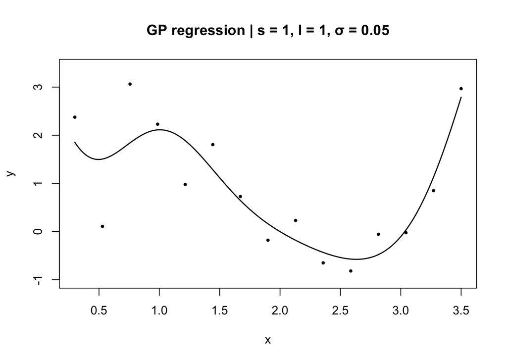

Let’s optimise them. Note that, for both numerical stability and convenience, the optimisation problem is recast:
$$\underset{s^2,l,\sigma^2}{\operatorname{argmin}}
-2\log f(y|s^2,l,\sigma^2) =
\underset{s^2,l,\sigma^2}{\operatorname{argmax}}
f(y|s^2,l,\sigma^2).$$
Also note that, as the number of data points increases, the determinant will quickly blow up. So, in practice, we should not directly compute $\log(|K+\sigma^2I|)$. Instead, use
$$\log(|K+\sigma^2I|) = \log\left(\prod_{i=1}^n
U_{ii}^2\right) = 2\sum_{i=1}^n\log U_{ii},$$
where $U$ is the upper triangular factor of the [Cholesky decomposition](https://en.wikipedia.org/wiki/Cholesky_decomposition) of $K+\sigma^2I$, and $U_{ii}$ is each of the diagonal elements.

```r
# Objective : -2*(Log Marginal Likelihood)
L <- function(theta) {
  K22 <- kk(X, theta=theta) + diag(theta[3]^2, n)
  # nlog(2pi) is constant and dropped
  return( 2*sum(log(diag(chol(K22)))) + t(y)%*%solve(K22,y) )
}

# Minimisation
theta0 <- c(1, 1, 0.1)
lb <- c(0.1, 0.1, 0)
ub <- c(3, 3, 0.5) # small noise assumed
re <- optim(theta0, L, method="L-BFGS-B", lower=lb, upper=ub)
re$par
```

```
## [1] 1.6014415 0.2678021 0.0000000
```

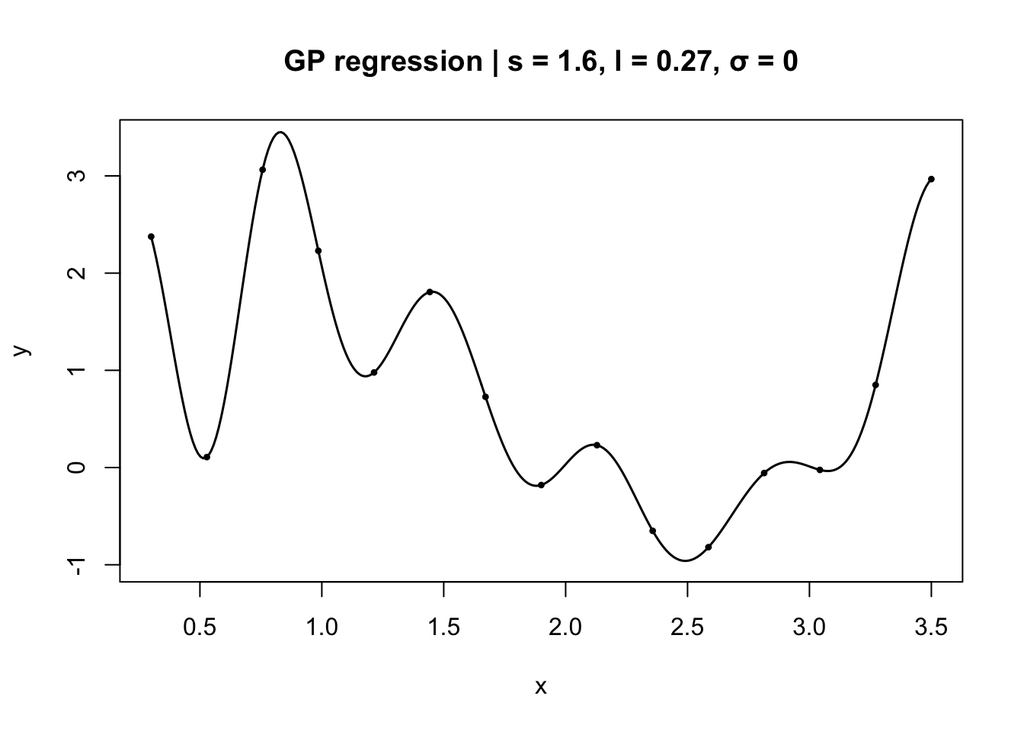

Hyperparameter optimisation is not and should not be easy; otherwise, GP would be a magical tool. Remember that GP is nonparametric models (no direct parameter to fit) whose behaviour is solely controlled by hyperparameters. In practice, it is often required to carefully set initial points and constraints. When calling `optim` above, for example, the small noise range $\sigma\in[0,0.5]$ reflects our knowledge about the measurement system (e.g. reliable sensors with small noise).

# Acquisition function

Performance of BO depends on qualities of both surrogate models and acquisition functions. While some researchers emphasise the latter, the former tends to be more important in practice—how well the surrogate GP captures key characteristics of the objective function. Also note that, when BO is used for deterministic objective functions, there will be no observation noise. To focus on unique aspects of BO, here, let’s assume
$$m(x_i) = 0,\quad k(x_i,x_j) =
\exp(-\|x_i-x_j\|^2), \quad\text{and}\quad \sigma^2=0.$$

## Efficient sequential evaluations

BO is often used when function evaluation is expensive; otherwise, we could simply search over a fine grid just like the above case at the beginning. If expensive, we need to locate a good minimiser within an evaluation budget or simply as quickly as possible.

An example story may be oil drilling. Before full production takes place, a company has to discover a good spot through test drilling. Suppose drilling a single hole and examining potential oil content under the ground cost a million dollars. So, the company wants to identify a good location conducting as few tests as possible. We may model the problem as follows:

- *Index set*. A testing site as a subset of $\mathbb{R}^2$.
- *Objective function*. A probability that a location $(x,y)$ contains a profitable amount of oil.
- *Evaluation of the objective*. Learning the probability at $(x,y)$ through drilling.

To understand the task, let’s sequentially plot both estimated mean function and 2-standard deviation band for increasing evaluation numbers.

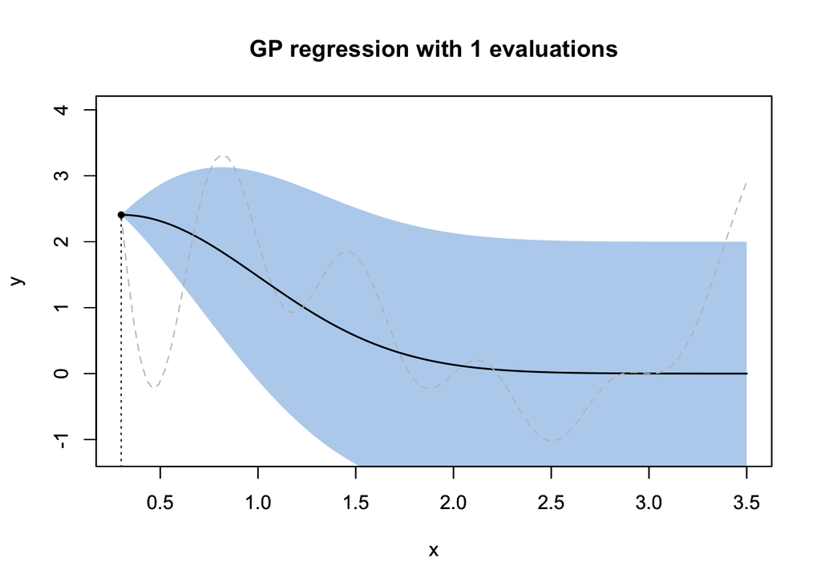

Clearly, as we evaluate more, the regression function improves with shrinking variance, and so does our estimate of minimiser. However, the order of evaluations matters. If we naively go from the left to the right…

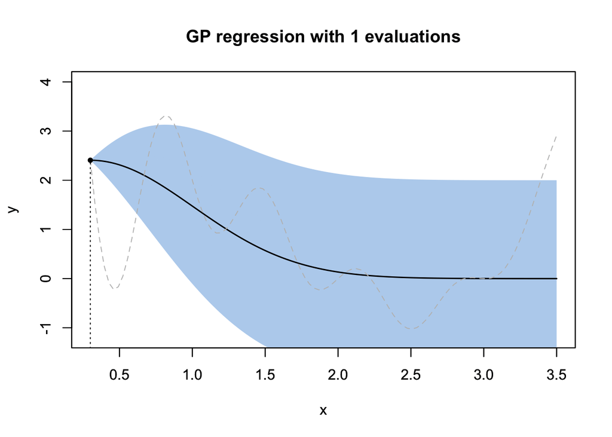

In other words, if we happened to evaluate a point near $x=2.5$, we would immediately have a good estimate of minimiser. But, of course, we do not know where the minimiser is. So, how should we proceed for efficient optimisation?

The acquisition function $\alpha(x|D_n)$ is **designed** and sequentially updated for this purpose such that it reflects decision maker’s preference over evaluation locations. It short, after $n$ evaluations, $(n+1)$th evaluation location is prescribed by maximising the acquisition function. Formally,
$$x_{n+1} \in \underset{x}{\operatorname{argmax}}\alpha(x|D_n).$$

> An implicit assumption is that evaluations of $\alpha$ is much cheaper than the objective $h$.

## Expected improvement

Decision makers’ preference over evaluation locations can be anything. Some of the simple ones are:

- *Risk averse*. They want to exploit the current knowledge and stick to the best estimate, i.e. $\alpha(x|D_n) = -\hat{\mu}(x)$
- *Curious*. They want to explore the region of highest variance, i.e. $\alpha(x|D_n) = \hat{K}(x)$
- *Balanced*. They want to balance the exploration-exploitation tradeoff.

The expected improvement acquisition function is designed for balanced decision makers. First, define “improvement” at $x$ to be:
$$\max\{0,\; y^* - \hat{g}(x)|D_n\},$$
where $y^*=\min\{y_1,\dots,y_{n}\}$. Then, we take expectation to get
$$\alpha_{EI}(x|D_n) = \mathbb{E}\left[\max\{0,\;
y^*-\hat{g}(x)\}\big|D_n\right].$$

Furthermore, the fact that $\hat{g}(x)|D_n$ is distributed as $\mathrm{N}(\hat{\mu}(x),\hat{K}(x))$ permits a closed-form expression:
$$\alpha_{EI}(x|D_n) =
(y^*-\hat{\mu}(x))\Phi(\bar{y}) +
\sqrt{\hat{K}(x)}\phi(\bar{y}),$$
where $\Phi$ is the standard normal CDF, and $\phi$ is the standard normal PDF, and
$$\bar{y} =
\frac{y^*-\hat{\mu}(x)}{\sqrt{\hat{K}(x)}}.$$

```r
# Expected improvement
ei <- function(x) {
  x <- matrix(x, ncol=1)
  K11 <- kk(x)
  K12 <- kk(x, X)
  K21 <- t(K12)
  K22 <- kk(X) + diag(1e-9, dim(X)[1])

  mu.hat <- K12%*%solve(K22,y)
  K.hat <- K11 - K12%*%solve(K22,K21)
  sigma <- sqrt(K.hat)
  d <- y.star - mu.hat # difference
  y.bar <- d/sigma # difference normalised

  return(d*pnorm(y.bar) + sigma*dnorm(y.bar))
}
```

### Demo

Suppose we have evaluated the objective at the midpoint $x_1=1.9$ or $D_1 = \{(1.9,f(1.9))\}$. Then, we have
$$\begin{align}
\hat{\mu}(x) &= \mathbf{k}(x,X)\mathbf{k}(X,X)^{-1}y\\
\hat{K}(x) &= k(x,x) - \mathbf{k}(x,X) \mathbf{k}(X,X)^{-1}
\mathbf{k}(X,x),
\end{align}$$
and $y^* = f(1.9) = -0.22$. With these, we can define $\alpha_{EI}(x|D_1)$ and maximise it to get
$$x_2\in\underset{x}{\operatorname{argmax}}\alpha_{EI}(x|D_1),$$
which is $x_2=0.69$. After obtaining $D_2 = \{(1.9,f(1.9)), (0.69, f(0.69))\}$, we repeat the process.

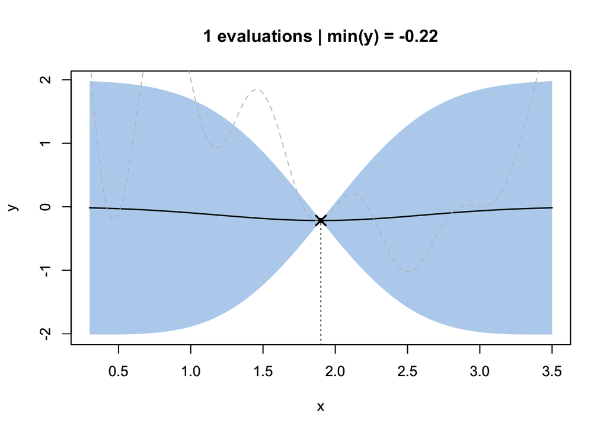

Knowing $h(2.5) = -1.025$ as the global minimum, reaching $h(2.52) = -1.02$ with only 9 evaluations seems efficient. But, in many practical applications, we do not know the exact global minimum and have to use other performance metrics.

# References

- Gramacy, R. B. (2020). *Surrogates: Gaussian process modeling, design, and optimization for the applied sciences*. Chapman and Hall/CRC.
- Rasmussen, C. E., & Williams, C. K. (2005). *Gaussian processes for machine learning*. Cambridge, MA: MIT press.
- Schaback, R., & Wendland, H. (2006). *Kernel techniques: From machine learning to meshless methods*. Acta Numerica, 15, 543–639.
- Shahriari, B., Swersky, K., Wang, Z., Adams, R. P., & De Freitas, N. (2015). *Taking the human out of the loop: A review of Bayesian optimization*. Proceedings of the IEEE, 104(1), 148–175.